# WHP Exploration

Iris Foxfoot

4/14/2021

## Packages Used

library(raster) #Main raster library with nearly all functions used in this analysis

library(rgdal) #Spatial library - most functions used from rgdal are for vectors (shapefiles)

library(rasterVis) #Useful for raster visualizations

library(rgeos) #Need this library for topology operations on geometries

library(dplyr) #NOT spatial - this is a data wrangling library (is also part of tidyverse)

library(here) #sets up file path

library(sf) #also allows R to work with spatial data but as dataframes

library(sp) #allows R to work with spatial data

library(tidyverse) #for data wrangling

library(tmap) #makes interactive maps

library(kableExtra) #for tables

library(viridis) #for color

## Data Used

https://www.atsdr.cdc.gov/placeandhealth/svi/documentation/SVI_documentation_2018.html -CDC vulnerability index for 2018

https://www.firelab.org/sites/default/files/images/downloads/wfp_2012_classified_metadata_faq.pdf -USFS fire hazard potential

## Set up margins

```r
#setting smaller margins for plotting
par(mar=c(2,2,1,1))
```

## Reading in data

```r
#read in wildfire hazard potential raster layers

#this one has classes. 1 = low risk, 5 = highest risk, 6&7 represent water/non burnable areas
wph_cls <- raster(here("WPH_data","whp2020_cls_conus.tif"))

#this one is continuous, higher values = higher fuel load (As I understand...)
wph_cont <- raster(here("WPH_data", "whp2020_cnt_conus.tif"))

#check it out
wph_cont
```

```
## class      : RasterLayer
## dimensions : 10803, 17132, 185076996  (nrow, ncol, ncell)
## resolution : 270, 270  (x, y)
## extent     : -2361825, 2263815, 258795, 3175605  (xmin, xmax, ymin, ymax)
## crs        : +proj=aea +lat_0=23 +lon_0=-96 +lat_1=29.5 +lat_2=45.5 +x_0=0 +y_0=0 +datum=NAD83 +units=m +no_defs
## source     : /Users/irisfoxfoot/Desktop/WHP_exploration_R/WPH_data/whp2020_cnt_conus.tif
## names      : whp2020_cnt_conus
## values     : -2147483648, 2147483647  (min, max)
```

```r
wph_cls
```

```
## class      : RasterLayer
## dimensions : 10803, 17132, 185076996  (nrow, ncol, ncell)
## resolution : 270, 270  (x, y)
## extent     : -2361825, 2263815, 258795, 3175605  (xmin, xmax, ymin, ymax)
## crs        : +proj=aea +lat_0=23 +lon_0=-96 +lat_1=29.5 +lat_2=45.5 +x_0=0 +y_0=0 +datum=NAD83 +units=m +no_defs
## source     : /Users/irisfoxfoot/Desktop/WHP_exploration_R/WPH_data/whp2020_cls_conus.tif
## names      : whp2020_cls_conus
## values     : 0, 255  (min, max)
```

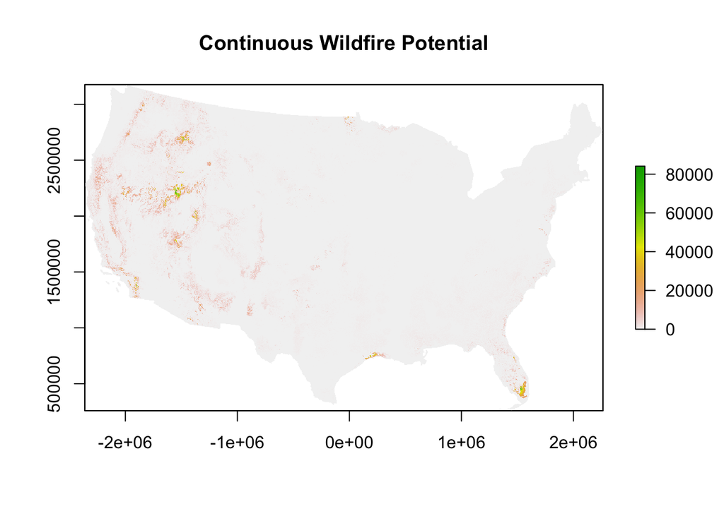

```r
# fixing classes
wph_cls <- reclassify(wph_cls, rcl=c(5,7,0))

#View it
plot(wph_cont, main = "Continuous Wildfire Potential")
```

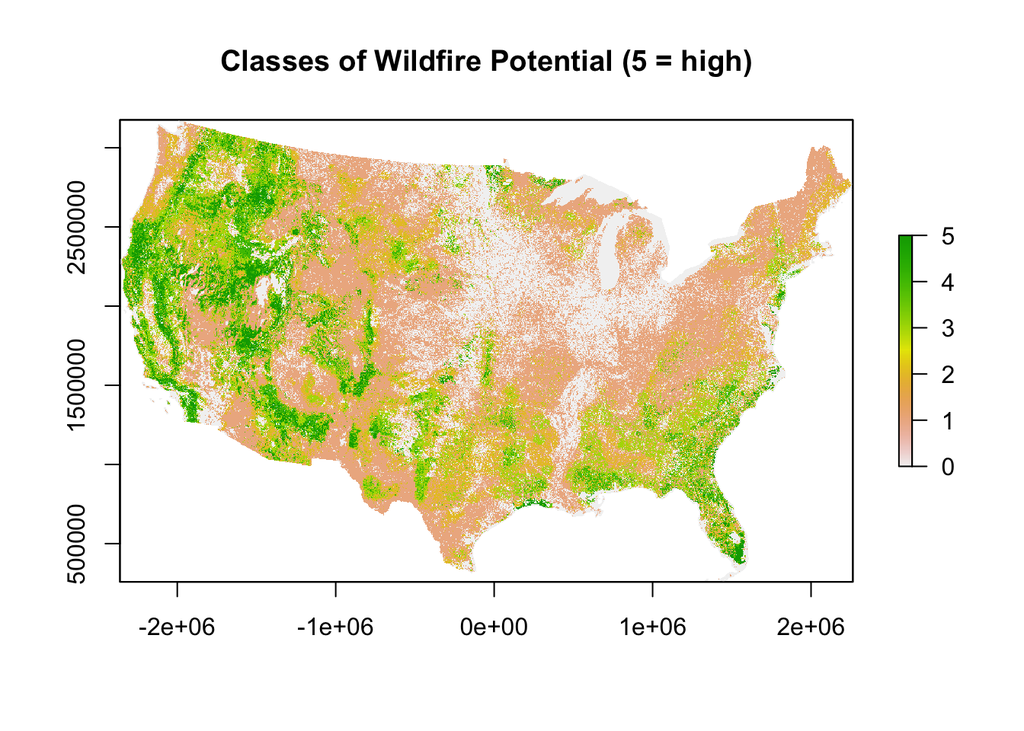

```r
plot(wph_cls, main = "Classes of Wildfire Potential (5 = high)")
```

```r
#read in ventura data (taken from CDC vulnerability index of CA at census level)
vuln_ca_tract <- st_read(here("California", "SVI2018_CALIFORNIA_tract.shp"))
```

## Data Wrangling

```r
#filter for Ventura census tracts
ventura_vuln_tract <- vuln_ca_tract %>%
  filter(COUNTY == "Ventura")
```

```r
#This is like the zonal statistics tool in GIS. I'm overlaying the census boundaries onto the raster of continuous fire risk and calculating the mean risk in each tract. It then appends it to the polygon layer, which is the census tracts of Ventura in this case.
extract_fire <- raster::extract(wph_cont, ventura_vuln_tract, method="simple", fun=mean, weights=TRUE, normalizeWeights=TRUE, sp = TRUE)
#NOTE I can't seem to get a function other than mean to work, it could have different results to calculate median risk per census tract...or some other statistic?

#Would be interesting to look at the wildfire hazard potential classes.
```

```r
#convert to sf (sf makes a polygon layer like a dataframe so you can use tidyverse commands on it)
extract_fire_sf <- st_as_sf(extract_fire)

#wrangle to show vulnerable communities
vulnerable_fire <- extract_fire_sf %>%
  filter(quantile(RPL_THEMES, 0.75)<RPL_THEMES) %>% #top quantile of vulnerability
  filter(quantile(whp2020_cnt_conus, 0.75)<whp2020_cnt_conus) #top quantile of fire risk

#change column names, split census name up so it's not so long
vulnerable_fire <- vulnerable_fire %>%
  rename(fire_risk_per_tract = whp2020_cnt_conus) %>%
  rename(vulnerability_per_tract = RPL_THEMES) %>%
  separate(LOCATION, c("census_tract", "county"), ",")
```

## Making a Table

```r
#select variables for a table
vulnerable_fire_table <- vulnerable_fire %>%
  select("census_tract", "fire_risk_per_tract", "vulnerability_per_tract")

#get rid of geometry info (it automatically "sticks" to the data unless you tell it not to)
st_geometry(vulnerable_fire_table) <- NULL

#table
vulnerable_fire_table %>%
  kbl(caption = "Top Quartile of Social Vulnerabilty and Fire Potential by Census Tract") %>%
   kable_classic(full_width = T, html_font = "Cambria")
```

Top Quartile of Social Vulnerabilty and Fire Potential by Census Tract

| census_tract | fire_risk_per_tract | vulnerability_per_tract |
| --- | --- | --- |
| Census Tract 2 | 1479.9371 | 0.7728 |
| Census Tract 3.02 | 3018.7972 | 0.8280 |
| Census Tract 3.04 | 1436.8859 | 0.7635 |
| Census Tract 4 | 1352.0260 | 0.6825 |
| Census Tract 5 | 425.7571 | 0.7823 |
| Census Tract 8 | 1662.5065 | 0.6426 |
| Census Tract 12.01 | 188.1554 | 0.6869 |
| Census Tract 13.02 | 122.2510 | 0.7607 |
| Census Tract 22 | 413.4791 | 0.8681 |
| Census Tract 23 | 157.6234 | 0.7842 |
| Census Tract 50.02 | 129.3943 | 0.8192 |

## Making a map

```r
#tmap -- interactive
tmap_mode("view")
tm_basemap("OpenStreetMap.HOT") +
tm_shape(vulnerable_fire) +
tm_polygons(c("fire_risk_per_tract", "vulnerability_per_tract"), alpha = 0.5, id = "census_tract", palette = "seq", legend.reverse = T) +
    tm_facets(sync = TRUE, ncol = 2)+
  tm_layout(aes.palette = list(seq = "-viridis"))
```

[interactive chart not shown]

## Next steps

- The CDC has a bunch of variables it uses to calculate vulnerability (see metadata linked). What are major drivers of vulnerability in these census tracts?
- Other ways to look at fire risk. Calculating median risk level per tract? Using the classes instead of the continuous raster? People who live on the edge of a tract are at risk from a fire outside of their tract, would it be better to calculate fire risk within a buffer zone around the tract? How large of a buffer?
- Should we include other “environmental” variables like # of roads for evac, number of fire stations, etc?